# Week 7: Building a ML End-to-End Project

## Lab1: Regression Machine Learning Case Study Project

# Import packages

```r
library(caret)
library(corrplot)
library(mlbench)

data(BostonHousing)
```

# Validation Dataset

```r
set.seed(7)

# Create a list of 80% of the rows in the original dataset we can use for training

validationIndex <- createDataPartition(BostonHousing$medv, p = .80, list = FALSE)

# Select 20% of the data for validation

validation <- BostonHousing[-validationIndex, ]

# Use the remaining 80% of data for training and testing the models

dataset <- BostonHousing[validationIndex, ]
```

# Analyse data

```r
# Dimensions of dataset

dim(dataset)
```

```
[1] 407  14
```

```r
# list types for each attribute

sapply(dataset, class)
```

```
     crim        zn     indus      chas       nox        rm       age       dis       rad       tax   ptratio         b     lstat      medv
"numeric" "numeric" "numeric"  "factor" "numeric" "numeric" "numeric" "numeric" "numeric" "numeric" "numeric" "numeric" "numeric" "numeric"
```

```r
# Take a peek at the first 20 rows of the dataset

head(dataset, n=20)
```

|  | crim | zn | indus | chas | nox | rm | age | dis | rad | tax | ptratio | b | lstat | medv |
| --- | --- | --- | --- | --- | --- | --- | --- | --- | --- | --- | --- | --- | --- | --- |
| 1 | 0.00632 | 18.0 | 2.31 | 0 | 0.538 | 6.575 | 65.2 | 4.0900 | 1 | 296 | 15.3 | 396.90 | 4.98 | 24.0 |
| 2 | 0.02731 | 0.0 | 7.07 | 0 | 0.469 | 6.421 | 78.9 | 4.9671 | 2 | 242 | 17.8 | 396.90 | 9.14 | 21.6 |
| 3 | 0.02729 | 0.0 | 7.07 | 0 | 0.469 | 7.185 | 61.1 | 4.9671 | 2 | 242 | 17.8 | 392.83 | 4.03 | 34.7 |
| 4 | 0.03237 | 0.0 | 2.18 | 0 | 0.458 | 6.998 | 45.8 | 6.0622 | 3 | 222 | 18.7 | 394.63 | 2.94 | 33.4 |
| 5 | 0.06905 | 0.0 | 2.18 | 0 | 0.458 | 7.147 | 54.2 | 6.0622 | 3 | 222 | 18.7 | 396.90 | 5.33 | 36.2 |
| 6 | 0.02985 | 0.0 | 2.18 | 0 | 0.458 | 6.430 | 58.7 | 6.0622 | 3 | 222 | 18.7 | 394.12 | 5.21 | 28.7 |
| 7 | 0.08829 | 12.5 | 7.87 | 0 | 0.524 | 6.012 | 66.6 | 5.5605 | 5 | 311 | 15.2 | 395.60 | 12.43 | 22.9 |
| 10 | 0.17004 | 12.5 | 7.87 | 0 | 0.524 | 6.004 | 85.9 | 6.5921 | 5 | 311 | 15.2 | 386.71 | 17.10 | 18.9 |
| 11 | 0.22489 | 12.5 | 7.87 | 0 | 0.524 | 6.377 | 94.3 | 6.3467 | 5 | 311 | 15.2 | 392.52 | 20.45 | 15.0 |
| 12 | 0.11747 | 12.5 | 7.87 | 0 | 0.524 | 6.009 | 82.9 | 6.2267 | 5 | 311 | 15.2 | 396.90 | 13.27 | 18.9 |

[output cut: 10 more lines]

```r
# summarize attribute distributions

summary(dataset)
```

```
      crim                zn             indus       chas         nox               rm             age              dis              rad              tax
 Min.   : 0.00632   Min.   :  0.00   Min.   : 0.74   0:378   Min.   :0.3850   Min.   :3.561   Min.   :  6.20   Min.   : 1.130   Min.   : 1.000   Min.   :187.0
 1st Qu.: 0.07964   1st Qu.:  0.00   1st Qu.: 4.93   1: 29   1st Qu.:0.4480   1st Qu.:5.888   1st Qu.: 42.70   1st Qu.: 2.109   1st Qu.: 4.000   1st Qu.:280.5
 Median : 0.26838   Median :  0.00   Median : 8.56           Median :0.5380   Median :6.212   Median : 77.30   Median : 3.152   Median : 5.000   Median :334.0
 Mean   : 3.63725   Mean   : 11.92   Mean   :11.00           Mean   :0.5547   Mean   :6.290   Mean   : 68.38   Mean   : 3.818   Mean   : 9.595   Mean   :408.7
 3rd Qu.: 3.68567   3rd Qu.: 15.00   3rd Qu.:18.10           3rd Qu.:0.6310   3rd Qu.:6.619   3rd Qu.: 94.20   3rd Qu.: 5.215   3rd Qu.:24.000   3rd Qu.:666.0
 Max.   :88.97620   Max.   :100.00   Max.   :27.74           Max.   :0.8710   Max.   :8.780   Max.   :100.00   Max.   :12.127   Max.   :24.000   Max.   :711.0
    ptratio            b              lstat             medv
 Min.   :12.60   Min.   :  0.32   Min.   : 1.920   Min.   : 5.00
 1st Qu.:17.00   1st Qu.:373.81   1st Qu.: 7.065   1st Qu.:17.05
 Median :19.00   Median :391.27   Median :11.320   Median :21.20
 Mean   :18.42   Mean   :357.19   Mean   :12.556   Mean   :22.52
 3rd Qu.:20.20   3rd Qu.:396.02   3rd Qu.:16.455   3rd Qu.:25.00
 Max.   :22.00   Max.   :396.90   Max.   :37.970   Max.   :50.00
```

# Converting types and Coreelation

```r
# convert chas to a numeric attribute

dataset$chas <- as.numeric(as.character(dataset$chas))

# correlation between all the numeric attributes

cor(dataset[, sapply(dataset, is.numeric)])
```

```
               crim          zn      indus         chas        nox         rm         age         dis          rad         tax    ptratio           b       lstat
crim     1.00000000 -0.19958871  0.4075617 -0.055071619  0.4099499 -0.1939805  0.35240196 -0.37564969  0.608343448  0.57112501  0.2897046 -0.34424053  0.42294190
zn      -0.19958871  1.00000000 -0.5314446 -0.029869089 -0.5202171  0.3110684 -0.58447039  0.67986750 -0.322734034 -0.31839453 -0.3887793  0.17471792 -0.42188931
indus    0.40756169 -0.53144458  1.0000000  0.065834605  0.7732538 -0.3826220  0.65115470 -0.71134308  0.619984390  0.71851024  0.3781852 -0.36437143  0.61359140
chas    -0.05507162 -0.02986909  0.0658346  1.000000000  0.0933997  0.1267673  0.07350147 -0.09904614 -0.002445292 -0.03064433 -0.1228318  0.03782259 -0.08430458
nox      0.40994989 -0.52021705  0.7732538  0.093399699  1.0000000 -0.2960506  0.73382994 -0.76934256  0.627604694  0.67576249  0.1887657 -0.36838649  0.58389344
rm      -0.19398049  0.31106841 -0.3826220  0.126767331 -0.2960506  1.0000000 -0.22615708  0.20745239 -0.221261630 -0.29526853 -0.3648317  0.12599418 -0.61195203
age      0.35240196 -0.58447039  0.6511547  0.073501472  0.7338299 -0.2261571  1.00000000 -0.74924225  0.468963375  0.50581099  0.2709298 -0.27418512  0.60664241
dis     -0.37564969  0.67986750 -0.7113431 -0.099046145 -0.7693426  0.2074524 -0.74924225  1.00000000 -0.503720701 -0.52641543 -0.2279429  0.28427693 -0.50129941
rad      0.60834345 -0.32273403  0.6199844 -0.002445292  0.6276047 -0.2212616  0.46896338 -0.50372070  1.000000000  0.92005320  0.4797148 -0.42313915  0.50251178
tax      0.57112501 -0.31839453  0.7185102 -0.030644325  0.6757625 -0.2952685  0.50581099 -0.52641543  0.920053202  1.00000000  0.4690561 -0.43026638  0.55382142
ptratio  0.28970459 -0.38877931  0.3781852 -0.122831776  0.1887657 -0.3648317  0.27092980 -0.22794289  0.479714803  0.46905607  1.0000000 -0.16996117  0.40927864
b       -0.34424053  0.17471792 -0.3643714  0.037822587 -0.3683865  0.1259942 -0.27418512  0.28427693 -0.423139153 -0.43026638 -0.1699612  1.00000000 -0.35088088
lstat    0.42294190 -0.42188931  0.6135914 -0.084304578  0.5838934 -0.6119520  0.60664241 -0.50129941  0.502511782  0.55382142  0.4092786 -0.35088088  1.00000000
medv    -0.38626655  0.37663074 -0.4981141  0.200817928 -0.4351560  0.6971576 -0.39044828  0.26469833 -0.414463464 -0.49793525 -0.5288296  0.32145408 -0.73807793
              medv
crim    -0.3862665
zn       0.3766307
indus   -0.4981141
chas     0.2008179
nox     -0.4351560
rm       0.6971576
age     -0.3904483
dis      0.2646983
rad     -0.4144635
tax     -0.4979352
ptratio -0.5288296
b        0.3214541
lstat   -0.7380779
medv     1.0000000
```

# Unimodal data visualizations

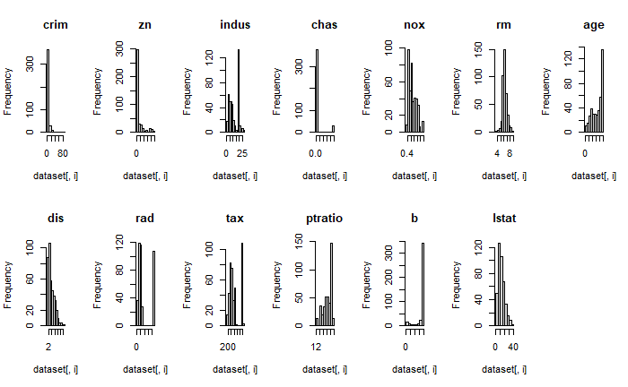

```r
# histograms each attribute

par(mfrow = c(2,7))

for (i in 1:13) {
  hist(dataset[, i], main = names(dataset)[i])

}
```

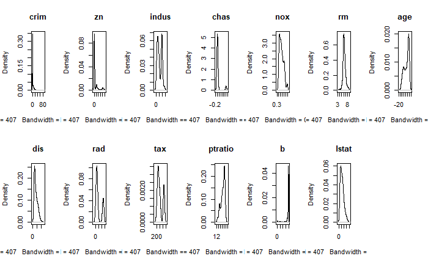

```r
# density plot for each attribute

par(mfrow = c(2,7))
for (i in 1:13) {
  plot(density(dataset[,i]), main = names(dataset)[i])

}
```

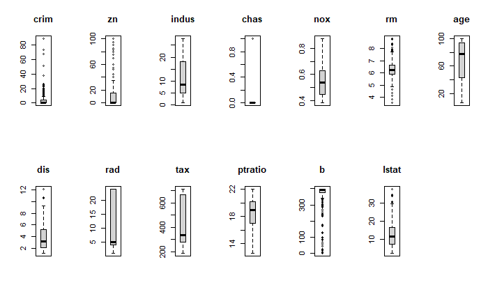

```r
# Boxplots for each attribute

par(mfrow = c(2,7))
for (i in 1:13) {
  boxplot(dataset[,i], main = names(dataset)[i])

}
```

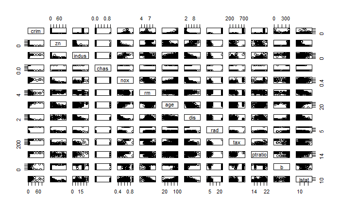

```r
# scatterplot matrix

pairs(dataset[,1:13])
```

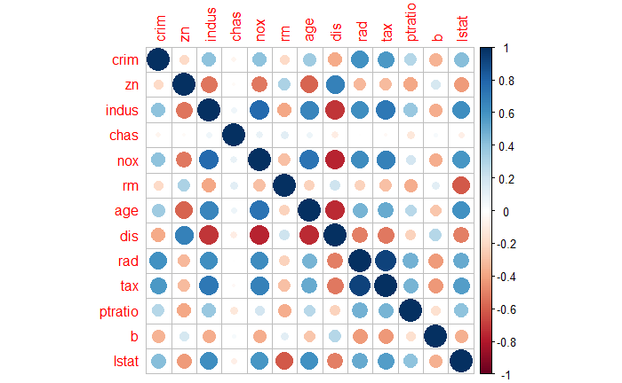

```r
# correlation plot

correlations <- cor(dataset[,1:13])

corrplot(correlations, method = "circle")
```

# Cross validation

Cross-validation is a technique used in statistics and machine learning to evaluate the performance of a model. It helps ensure that the model generalizes well to new, unseen data. Here’s a simple breakdown:

Purpose: The main goal of cross-validation is to test the model’s ability to predict new data that wasn’t used during training. This helps in identifying issues like overfitting, where the model performs well on training data but poorly on new data.

Process: The data is divided into multiple subsets or “folds”. The model is trained on some of these folds and tested on the remaining ones. This process is repeated several times, each time using a different fold as the test set. The results are then averaged to get a more accurate estimate of the model’s performance.

Types: K-Fold Cross-Validation: The data is divided into ‘k’ subsets. The model is trained on ‘k-1’ subsets and tested on the remaining one. This is repeated ‘k’ times.

Leave-One-Out Cross-Validation (LOOCV): Each data point is used once as a test set while the rest are used for training. This is repeated for each data point.

Holdout Validation: The data is split into two sets, one for training and one for testing. This is simpler but less reliable than k-fold cross-validation

```r
# Prepare the test harness for evaluating algorithms

# Run algorithms using 10-fold cross validation

trainControl <- trainControl(method = "repeatedcv", number = 10, repeats = 3)

metric <- "RMSE"
```

# Estimate accuracy of machine learning algorithms

```r
#LM
set.seed(7)
fit.lm <- train(medv~., data = dataset, method = 'lm', metric = metric, preProc = c("center", "scale"), trControl = trainControl)


# GLM
set.seed(7)
fit.glm <- train(medv~., data = dataset, method = 'glm', metric = metric, preProc = c("center", "scale"), trControl = trainControl)

# GLMNET
set.seed(7)
fit.glmnet <- train(medv~., data = dataset, method = 'glmnet', metric = metric, preProc = c("center", "scale"), trControl = trainControl)

# SVM
set.seed(7)
fit.svm <- train(medv~., data = dataset, method = 'svmRadial', metric = metric, preProc = c("center", "scale"), trControl = trainControl)
```

```
1 package is needed and is not installed. (kernlab). Would you like to try to install it now?
1: yes
2: no
```

```r
1
# CART
set.seed(7)
grid <- expand.grid(.cp= c(0, 0.5, 0.1))
fit.cart <- train(medv~., data = dataset, method = 'rpart', metric = metric, tuneGrid = grid, preProc = c("center", "scale"), trControl = trainControl)
# KNN
set.seed(7)
fit.knn <- train(medv~., data = dataset, method = 'knn', metric = metric, preProc = c("center", "scale"), trControl = trainControl)
```

# Collect resampled statistics from models and summarise results

```r
# compare algorithms

results <- resamples(list(LM= fit.lm, GLM = fit.glm, GLMNET = fit.glmnet, SVM = fit.svm, CART = fit.cart, KNN = fit.knn))

summary(results)
```

```
Call:
summary.resamples(object = results)

Models: LM, GLM, GLMNET, SVM, CART, KNN
Number of resamples: 30

MAE
           Min.  1st Qu.   Median     Mean  3rd Qu.     Max. NA's
LM     2.296870 2.897637 3.368197 3.315490 3.701331 4.644634    0
GLM    2.296870 2.897637 3.368197 3.315490 3.701331 4.644634    0
GLMNET 2.300353 2.883646 3.336121 3.304888 3.697932 4.625185    0
SVM    1.422339 1.992016 2.516175 2.387512 2.654770 3.345278    0
CART   2.216672 2.620729 2.883975 2.933934 3.081861 4.161930    0
KNN    1.978049 2.685764 2.866806 2.947500 3.237153 3.998333    0

RMSE
           Min.  1st Qu.   Median     Mean  3rd Qu.     Max. NA's
LM     2.991624 3.869651 4.632032 4.629323 5.317398 6.694651    0
GLM    2.991624 3.869651 4.632032 4.629323 5.317398 6.694651    0
GLMNET 2.990832 3.878814 4.615843 4.624746 5.316638 6.692580    0
SVM    2.049504 2.949764 3.814475 3.908810 4.455599 6.979067    0
CART   2.766558 3.379400 3.997915 4.199124 4.600681 7.087656    0
KNN    2.653686 3.741499 4.415526 4.482558 5.064124 6.976913    0

Rsquared
            Min.   1st Qu.    Median      Mean   3rd Qu.      Max. NA's
LM     0.5050763 0.6744319 0.7474419 0.7404282 0.8127596 0.8999946    0
GLM    0.5050763 0.6744319 0.7474419 0.7404282 0.8127596 0.8999946    0
GLMNET 0.5033006 0.6730052 0.7474746 0.7410698 0.8155090 0.9039292    0
SVM    0.5193410 0.7623629 0.8447057 0.8103278 0.8958487 0.9700852    0
CART   0.5144771 0.7367598 0.8156225 0.7782237 0.8421169 0.8989506    0
KNN    0.5187652 0.7478699 0.8043069 0.7699680 0.8293089 0.9307667    0
```

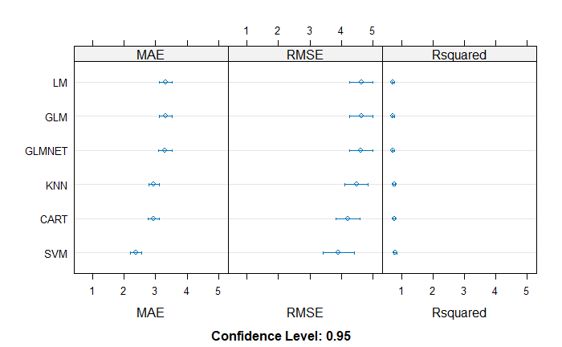

```r
dotplot(results)
```

It looks like SVM has the lowest RMSE, followed by the other non-linear algorithms CART and KNN. The linear regression algorithms all appear to be in the same ballpark with slightly worse error.

We can also see that SVM and the other non-linear algorithms have the best fit for the data in their r2 measures.

Did centering and scaling make a difference to the algorithms other than KNN? Doubtful, and best to hold the data constant at this stage. Perhaps the worse performance of the linear algorithms has something to do with the highly correlated attributes. Let’s look at that in the next section.